# Índice de Credibilidade para Bancos Centrais

Victor Alves

2023-01-02

# Carregando pacotes

```r
library(rbcb) # dados para o Banco Central do Brasil
library(tidyverse) # manipulação e visualização de dados
library(lubridate) # manipulação de datas
library(zoo)
library(rvest)
library(xml2)
library(paletteer)
```

# Limpeza de dados

```r
setwd(dirname(rstudioapi::getActiveDocumentContext()$path)) # defininindo diretório como pasta onde o arquivo está
`%not_in%` <- purrr::negate(`%in%`) # crianção de operador para negação de pertencimento
```

## Dados para o Brasil

Para obtenção dos dados de inflação meta para o Brasil, foram utilzadas as informações presentes no site [Histórico das metas para a inflação](https://www.bcb.gov.br/controleinflacao/historicometas), do BCB. Para isso, foi utilizada uma função do Excel para obtenção de tabelas via HTML. O próximo passo aqui é definir uma maneira de raspar automaticamente esta tabela via R.

```r
# inflação meta
brazil_target <- readxl::read_xlsx('Dados/brazil_target.xlsx') %>%
  select(-c(Norma, Data,
            `Tamanho do intervalo +/- (p.p.)`, `Inflação efetiva (Variação do IPCA, %)`)) %>%
  mutate(
    Ano = case_when(Ano == '2003*' ~ '2003',
              Ano == '2004*' ~ '2004',
              TRUE ~ Ano)) %>%
  separate_rows(`Meta (%)`, `Intervalo de tolerância (%)`, convert = TRUE, sep = '\n') %>%
  separate(
    col = `Intervalo de tolerância (%)`,
    into = c('inferior', 'superior'),
    sep = '-'
  ) %>%
  rename(meta = `Meta (%)`,
         year = Ano) %>%
  mutate(meta = str_replace(meta, ",", "."),
         inferior = str_replace(inferior, ",", "."),
         superior = str_replace(superior, ",", ".")) %>%
  mutate(meta = iconv(meta, 'utf-8', 'ascii', sub=''),
         inferior = as.numeric(inferior),
         superior = as.numeric(superior),
         year = as.numeric(year))
```

Para obtenção das expectativas do mercado, foi utilizada uma função do pacote ‘rbcb’ para obter um dataframe para o relatório FOCUS.\ Em primeiro momento se tomará apenas a inflação corrente para o ano seguinte. Tendo também como objetivo para expansão o cálculo com base na inflação esperada para os anos seguintes, se buscará outras funções para obtenção destes dados.\ O dataframe ainda possui um erro importante. Para os anos em que o FOCUS saiu muito próximo do dia 31/12, a função de conversão de semanas para dia/mês/ano está inserindo NA. Como forma de contornar este problema, será assumido que a data não existente é o último dia do ano.

```r
# inflação esperada do Brasil
brazil_forecast <- get_annual_market_expectations('IPCA') %>%
  filter(base == 0) %>%
  mutate(week = week(ymd(date)),
         year = year(ymd(date)),
         current = case_when(year == reference_date ~ 1,
                             TRUE ~ 0)) %>%
  filter(current == 1) %>%
  group_by(week, year, reference_date) %>%
  summarise(median = median(median)) %>%
  mutate(date = as.Date(paste(year, week, 1, sep='-'), '%Y-%U-%u'),
         date = replace_na(date, as.Date(paste(year, 12, 31, sep = '-'))))
data_brazil <- right_join(brazil_target, brazil_forecast, by = 'year') %>%
  select(-c(year, week, reference_date)) %>%
  rename(date = date,
         expectative = median,
         current = meta) %>%
  mutate(country = 'Brasil',
         regime = 'interval',
         date = as_date(date, format = '%Y-%m-%d'))
```

## Dados para o Canadá

Os dados para a inflação meta do Canadá foram obtidos com base no site [Inflation-Control Target](https://www.bankofcanada.ca/rates/indicators/key-variables/inflation-control-target/).

```r
# inflação meta
canada_target <- read.csv('Dados/canada_target.csv',
                          skip = 19) %>%
  rename(inferior = STATIC_ATABLE_CPILL,
         superior = STATIC_ATABLE_CPIHL,
         current = STATIC_ATABLE_V41690973) %>%
  mutate(date = as.yearqtr(date,
                           format = "%Y-%m-%d"))
```

Os dados para a inflação esperada do Canadá foram obtidos com base no site [Expectations: Definitions, Graphs and Data](https://www.bankofcanada.ca/rates/indicators/capacity-and-inflation-pressures/expectations/). Esses dados precisarão ser revistos dado que há alguns sinais de erros para ele.

```r
# inflação esperada
canada_forecast <- read.csv('Dados/canada_forecast.csv',
                            skip = 27, na.strings = "") %>%
  select(date, INDINF_EXPECTTWOTHREE_Q) %>%
  mutate(date = str_replace(date, "Q", " Q"),
         date = as.yearqtr(date)) %>%
  rename(expectative = INDINF_EXPECTTWOTHREE_Q)
```

```r
data_canada <- right_join(canada_target, canada_forecast, by = 'date') %>%
  separate(date, into = c('year', 'quarter'), sep = ' ') %>%
  mutate(
    month = case_when(quarter == 'Q1' ~ '01/01',
                      quarter == 'Q2' ~ '01/04',
                      quarter == 'Q3' ~ '01/07',
                      quarter == 'Q4' ~ '01/12',
                      TRUE ~ quarter),
    country = 'Canada',
    regime = 'interval') %>%
  unite(date, month, year, sep = "/") %>%
  select(-c(quarter)) %>%
  mutate(date = as_date(date, format = '%d/%m/%Y')) %>%
  drop_na()
```

## Dados para a Argentina

Os dados para as expectativas de mercado foram obtidos com base no no [Relevamiento de Expectativas de Mercado (REM)](https://www.bcra.gob.ar/publicacionesestadisticas/relevamiento_expectativas_de_mercado.asp).\ A base aqui criada, contará somente com a inflação esperada para o ano corrente, sendo que na base original pode-se obter os valores para anos seguintes. Sendo assim, serão buscadas formas de também se considerar estes valores futuramente para o cálculo de um índice com base neles.\

```r
argentina_forecast <- readxl::read_xlsx('Dados/argentina_forecast.xlsx',
                                        sheet = 2,
                                        skip = 1) %>%
  select(-c(Promedio:`Cantidad de participantes`)) %>%
  filter(Variable == 'Precios minoristas (IPC nivel general; INDEC)',
         Referencia %in% c('var. % i.a.; dic-16', 'var. % i.a.; dic-17',
                           'var. % i.a.; dic-18', 'var. % i.a.; dic-19',
                           'var. % i.a.; dic-20', 'var. % i.a.; dic-21',
                           'var. % i.a.; dic-22', 'var. % i.a.; dic-23',
                           'var. % i.a.; dic-24'),
         Período %in% c('2016', '2017', '2018', '2019',
                        '2020', '2021', '2022', '2023', '2024')) %>%
  select(-c(Variable, Referencia)) %>%
  rename(date = `Fecha de pronóstico`,
         reference_date = Período,
         expectative = Mediana) %>%
  mutate(year = year(ymd(date)),
         current = case_when(year == reference_date ~ 1,
                             TRUE ~ 0)) %>%
  filter(current == 1) %>%
  select(-c(current, reference_date))
```

Infelizmente não há uma base unificada para o regime de metas de inflação para a Argetina. Portanto, será criado manualmente um dataframe com base nos dados presentes em [Monetary Policy](https://www.bcra.gob.ar/PoliticaMonetaria/Politica_Monetaria_i.asp). Futuramente se buscará uma forma automatizada de se coletar estes dados.

```r
argentina_target <- tibble(year = c(2019, 2020, 2021, 2022, 2023, 2024),
                           current = c(17, 13, 9, 5, 5, 5),
                           superior = c(NA, NA, NA, NA, NA, NA),
                           inferior = c(NA, NA, NA, NA, NA, NA))
```

```r
data_argentina <- right_join(argentina_target, argentina_forecast, by = 'year') %>%
  select(-year) %>%
  mutate(country = 'Argentina',
         regime = 'target')
```

# Base de dados final

Para o cálculo do índice de credibilidade foi utilizado o índice sugerido por [Levieuge, Lucotte, Ringuedé (2015)](https://econpapers.repec.org/paper/nbpnbpmis/209.htm).\ Sendo assim, assumindo que valores abaixo da meta (ou intervalo da meta) geram perda de credibilidade. O índice é construído tendo como condição o fato de o Banco Central ter um regime com meta ou com intervalo de meta. Deste modo, sendo $\pi^e$ a inflação esperada, $\bar{\pi}$ a inflação meta e $\pi^{\min} \pi^{\max}$ os limites do intervalo da meta.\

- Caso o Banco Central tenha um valor fixo de inflação meta:

$\text{credibility} = \dfrac{1}{exp(\pi^e - \bar{\pi}) - (\pi^e - \bar{\pi})}$\ * Caso o Banco Central tenha um valor em intervalo de inflação meta:

$\text{credibility} = \begin{cases} \dfrac{1}{exp(\pi^e - \bar{\pi^{\min}}) - (\pi^e - \bar{\pi}^{\min})}, & \text{se } \pi^e<\bar{\pi}^{\min}\\ 1, & \text{se } \pi \in \left[\bar{\pi}^\min, \bar{\pi}^\max \right]\\ \dfrac{1}{exp(\pi^e - \bar{\pi^{\max}}) - (\pi^e - \bar{\pi}^{\max})}, & \text{se } \pi^e>\bar{\pi}^{\max} \end{cases}$\

```r
database <- rbind(data_brazil, data_canada, data_argentina) %>%
    mutate(
    current = as.numeric(current),
    credibility = case_when(
      regime == 'interval' & expectative < inferior ~ 1/(exp(expectative - inferior) - (expectative - inferior)),
      regime == 'interval' & expectative >= inferior & expectative <= superior ~ 1,
      regime == 'interval' & expectative > superior ~ 1/(exp(expectative - superior) - (expectative - superior)),
      regime == 'target' ~ 1/(exp(expectative - current) - (expectative - current))
    )
  )
```

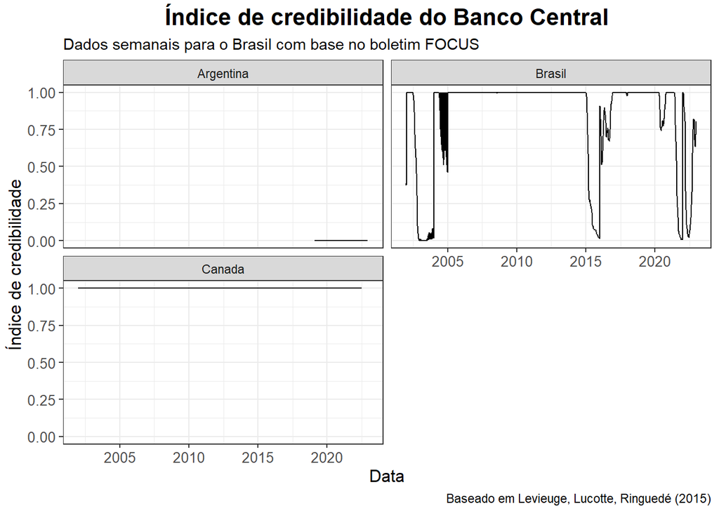

```r
database %>%
  ggplot() +
  geom_line(aes(date, credibility)) +
  scale_x_date(limits = as.Date(c("2001-12-12", "2022-12-30"))) +
  labs(title = 'Índice de credibilidade do Banco Central',
       subtitle = 'Dados semanais para o Brasil com base no boletim FOCUS',
       x = 'Data',
       y = 'Índice de credibilidade',
       caption = 'Baseado em Levieuge, Lucotte, Ringuedé (2015)',
       color = 'País') +
  theme_bw() +
  theme(
    plot.title=element_text(size=16, face="bold", hjust = 0.5),
    legend.text=element_text(size=10),
    axis.text=element_text(size=10),
    axis.title = element_text(size = 12),
    legend.title = element_text(size = 10)) +
  scale_color_grey() +
  facet_wrap(vars(country), ncol = 2)
```